# 05_add_vectors

## 05_add_vectors

#### Question

1. We are given two vectors: $\vec{A}$ and $\vec{B}$. Each vector has a direction and magnitude. The direction is given in radians counterclockwise from the positive $x$ axis. The magnitude is the length of the vector.

   Vector $\vec{A}$ is directed 5.87 radians counterclockwise from the positive $x$ axis, and it has a magnitude of 64.9.

   $$\theta_{\vec{A}}=5.87$$
   $$||\vec{A}||=64.9$$

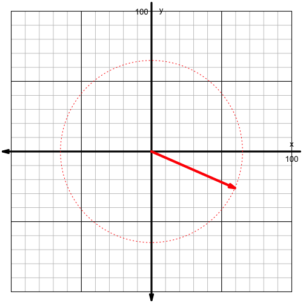

   vector A

   Vector $\vec{B}$ is directed 4.73 radians counterclockwise from the positive $x$ axis, and it has a magnitude of 54.6.

   $$\theta_{\vec{B}}=4.73$$
   $$||\vec{B}||=54.6$$

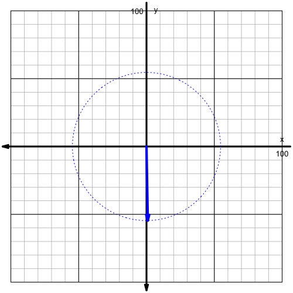

   vector B

   We are interested in a third vector, $\vec{C}$, which is the sum of the other two vectors.

   $$\vec{C}=\vec{A}+\vec{B}$$

   Graphically, to find the sum of two vectors, place the foot of the second vector at the head of the first vector, and then the resultant sum is the vector that goes from the foot of the first vector to the head of the second (shifted) vector. This will be easier to understand graphically:

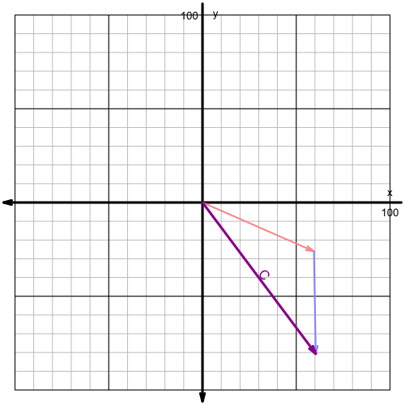

   vector C is the sum of vector A and vector B

   Find the direction (between 0 and $2\pi$) and magnitude of vector $\vec{C}$.
   - Direction:
   - Magnitude:

#### Question

2. We are given two vectors: $\vec{A}$ and $\vec{B}$. Each vector has a direction and magnitude. The direction is given in radians counterclockwise from the positive $x$ axis. The magnitude is the length of the vector.

   Vector $\vec{A}$ is directed 3.51 radians counterclockwise from the positive $x$ axis, and it has a magnitude of 44.6.

   $$\theta_{\vec{A}}=3.51$$
   $$||\vec{A}||=44.6$$

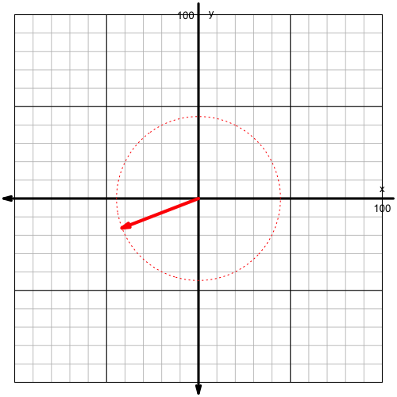

   vector A

   Vector $\vec{B}$ is directed 1.6 radians counterclockwise from the positive $x$ axis, and it has a magnitude of 43.1.

   $$\theta_{\vec{B}}=1.6$$
   $$||\vec{B}||=43.1$$

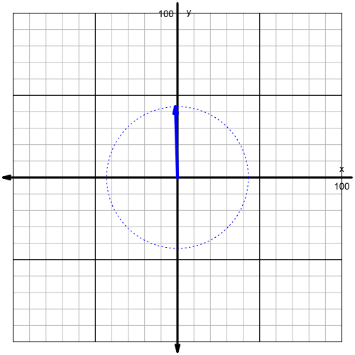

   vector B

   We are interested in a third vector, $\vec{C}$, which is the sum of the other two vectors.

   $$\vec{C}=\vec{A}+\vec{B}$$

   Graphically, to find the sum of two vectors, place the foot of the second vector at the head of the first vector, and then the resultant sum is the vector that goes from the foot of the first vector to the head of the second (shifted) vector. This will be easier to understand graphically:

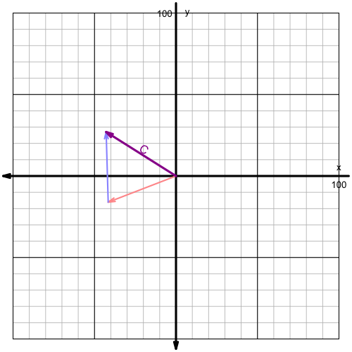

   vector C is the sum of vector A and vector B

   Find the direction (between 0 and $2\pi$) and magnitude of vector $\vec{C}$.
   - Direction:
   - Magnitude:

#### Question

3. We are given two vectors: $\vec{A}$ and $\vec{B}$. Each vector has a direction and magnitude. The direction is given in radians counterclockwise from the positive $x$ axis. The magnitude is the length of the vector.

   Vector $\vec{A}$ is directed 1.02 radians counterclockwise from the positive $x$ axis, and it has a magnitude of 73.3.

   $$\theta_{\vec{A}}=1.02$$
   $$||\vec{A}||=73.3$$

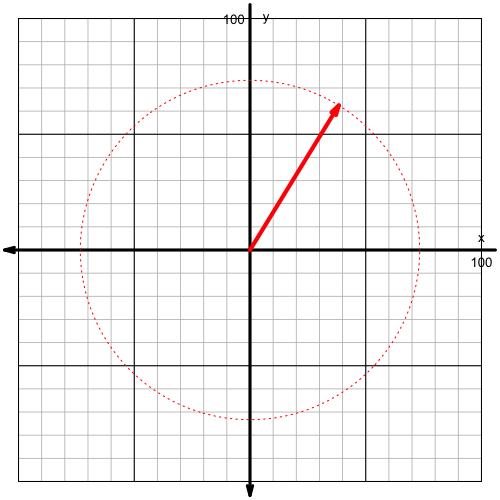

   vector A

   Vector $\vec{B}$ is directed 3.53 radians counterclockwise from the positive $x$ axis, and it has a magnitude of 64.5.

   $$\theta_{\vec{B}}=3.53$$
   $$||\vec{B}||=64.5$$

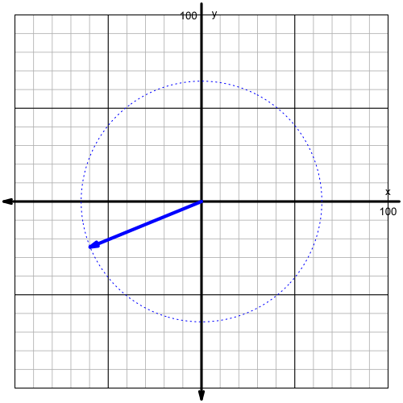

   vector B

   We are interested in a third vector, $\vec{C}$, which is the sum of the other two vectors.

   $$\vec{C}=\vec{A}+\vec{B}$$

   Graphically, to find the sum of two vectors, place the foot of the second vector at the head of the first vector, and then the resultant sum is the vector that goes from the foot of the first vector to the head of the second (shifted) vector. This will be easier to understand graphically:

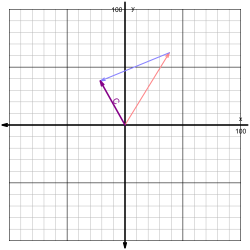

   vector C is the sum of vector A and vector B

   Find the direction (between 0 and $2\pi$) and magnitude of vector $\vec{C}$.
   - Direction:
   - Magnitude:

#### Question

4. We are given two vectors: $\vec{A}$ and $\vec{B}$. Each vector has a direction and magnitude. The direction is given in radians counterclockwise from the positive $x$ axis. The magnitude is the length of the vector.

   Vector $\vec{A}$ is directed 0.853 radians counterclockwise from the positive $x$ axis, and it has a magnitude of 48.5.

   $$\theta_{\vec{A}}=0.853$$
   $$||\vec{A}||=48.5$$

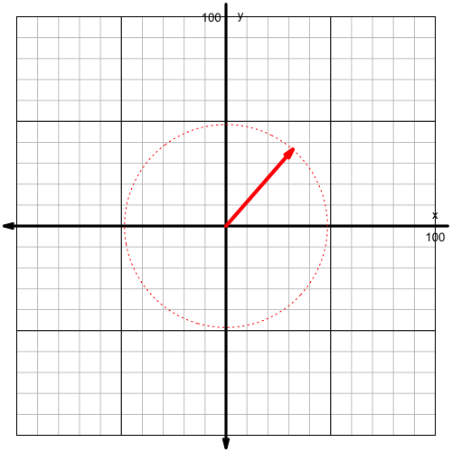

   vector A

   Vector $\vec{B}$ is directed 2.25 radians counterclockwise from the positive $x$ axis, and it has a magnitude of 69.5.

   $$\theta_{\vec{B}}=2.25$$
   $$||\vec{B}||=69.5$$

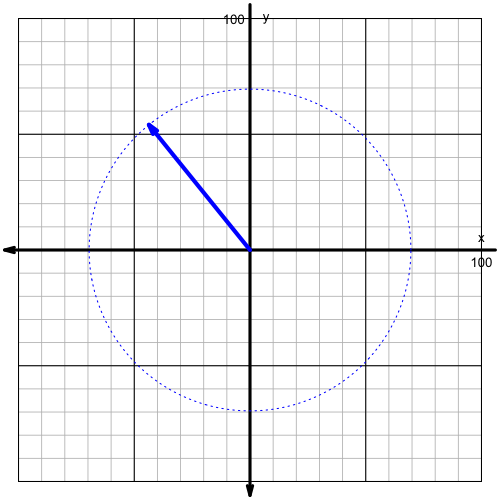

   vector B

   We are interested in a third vector, $\vec{C}$, which is the sum of the other two vectors.

   $$\vec{C}=\vec{A}+\vec{B}$$

   Graphically, to find the sum of two vectors, place the foot of the second vector at the head of the first vector, and then the resultant sum is the vector that goes from the foot of the first vector to the head of the second (shifted) vector. This will be easier to understand graphically:

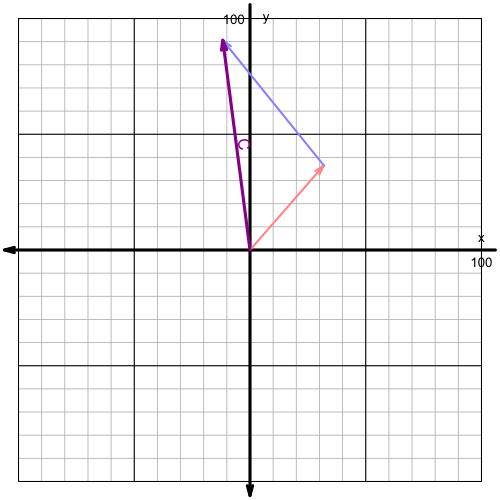

   vector C is the sum of vector A and vector B

   Find the direction (between 0 and $2\pi$) and magnitude of vector $\vec{C}$.
   - Direction:
   - Magnitude:

#### Question

5. We are given two vectors: $\vec{A}$ and $\vec{B}$. Each vector has a direction and magnitude. The direction is given in radians counterclockwise from the positive $x$ axis. The magnitude is the length of the vector.

   Vector $\vec{A}$ is directed 4.23 radians counterclockwise from the positive $x$ axis, and it has a magnitude of 56.

   $$\theta_{\vec{A}}=4.23$$
   $$||\vec{A}||=56$$

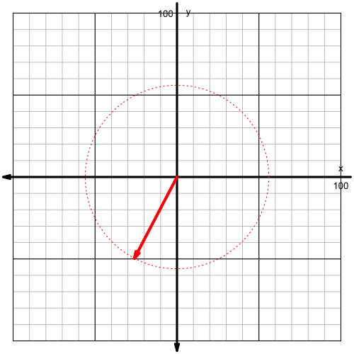

   vector A

   Vector $\vec{B}$ is directed 3.5 radians counterclockwise from the positive $x$ axis, and it has a magnitude of 65.5.

   $$\theta_{\vec{B}}=3.5$$
   $$||\vec{B}||=65.5$$

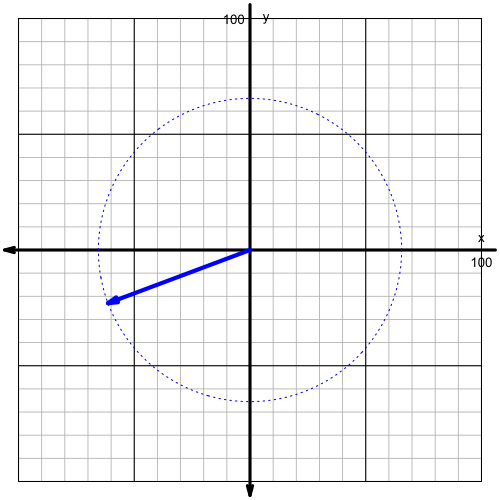

   vector B

   We are interested in a third vector, $\vec{C}$, which is the sum of the other two vectors.

   $$\vec{C}=\vec{A}+\vec{B}$$

   Graphically, to find the sum of two vectors, place the foot of the second vector at the head of the first vector, and then the resultant sum is the vector that goes from the foot of the first vector to the head of the second (shifted) vector. This will be easier to understand graphically:

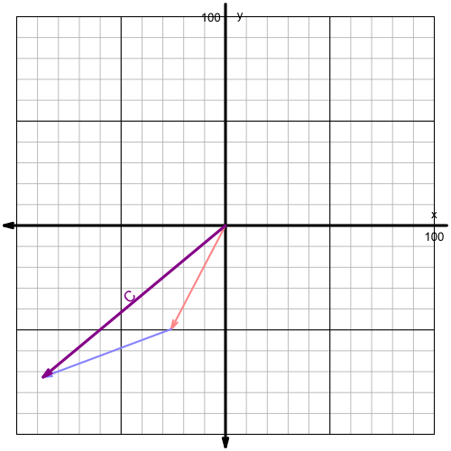

   vector C is the sum of vector A and vector B

   Find the direction (between 0 and $2\pi$) and magnitude of vector $\vec{C}$.
   - Direction:
   - Magnitude:

#### Question

6. We are given two vectors: $\vec{A}$ and $\vec{B}$. Each vector has a direction and magnitude. The direction is given in radians counterclockwise from the positive $x$ axis. The magnitude is the length of the vector.

   Vector $\vec{A}$ is directed 3.65 radians counterclockwise from the positive $x$ axis, and it has a magnitude of 93.7.

   $$\theta_{\vec{A}}=3.65$$
   $$||\vec{A}||=93.7$$

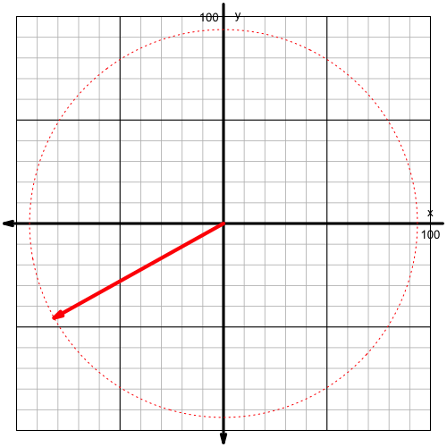

   vector A

   Vector $\vec{B}$ is directed 5.31 radians counterclockwise from the positive $x$ axis, and it has a magnitude of 42.

   $$\theta_{\vec{B}}=5.31$$
   $$||\vec{B}||=42$$

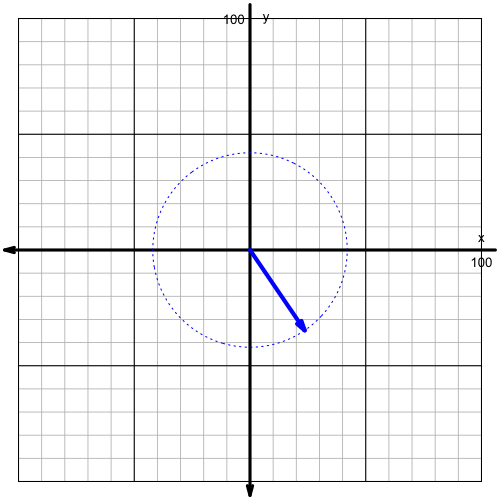

   vector B

   We are interested in a third vector, $\vec{C}$, which is the sum of the other two vectors.

   $$\vec{C}=\vec{A}+\vec{B}$$

   Graphically, to find the sum of two vectors, place the foot of the second vector at the head of the first vector, and then the resultant sum is the vector that goes from the foot of the first vector to the head of the second (shifted) vector. This will be easier to understand graphically:

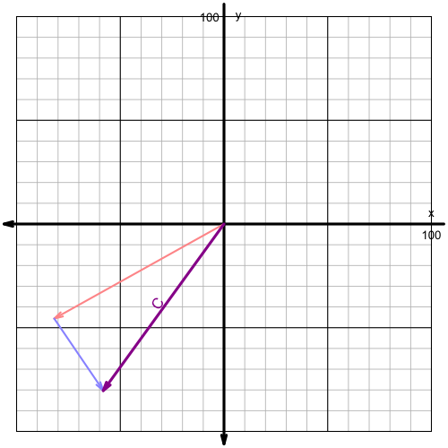

   vector C is the sum of vector A and vector B

   Find the direction (between 0 and $2\pi$) and magnitude of vector $\vec{C}$.
   - Direction:
   - Magnitude:

#### Question

7. We are given two vectors: $\vec{A}$ and $\vec{B}$. Each vector has a direction and magnitude. The direction is given in radians counterclockwise from the positive $x$ axis. The magnitude is the length of the vector.

   Vector $\vec{A}$ is directed 5.65 radians counterclockwise from the positive $x$ axis, and it has a magnitude of 65.4.

   $$\theta_{\vec{A}}=5.65$$
   $$||\vec{A}||=65.4$$

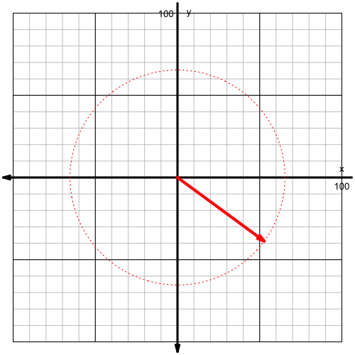

   vector A

   Vector $\vec{B}$ is directed 1.67 radians counterclockwise from the positive $x$ axis, and it has a magnitude of 52.4.

   $$\theta_{\vec{B}}=1.67$$
   $$||\vec{B}||=52.4$$

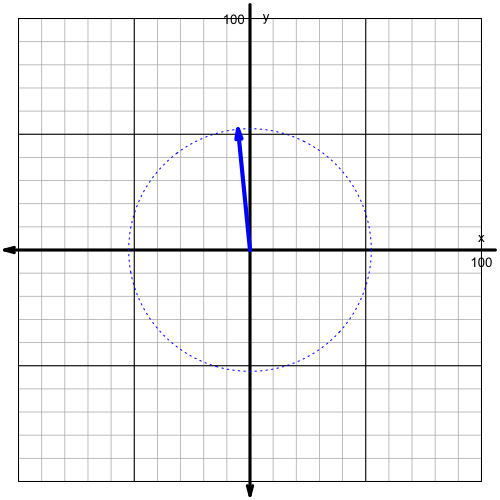

   vector B

   We are interested in a third vector, $\vec{C}$, which is the sum of the other two vectors.

   $$\vec{C}=\vec{A}+\vec{B}$$

   Graphically, to find the sum of two vectors, place the foot of the second vector at the head of the first vector, and then the resultant sum is the vector that goes from the foot of the first vector to the head of the second (shifted) vector. This will be easier to understand graphically:

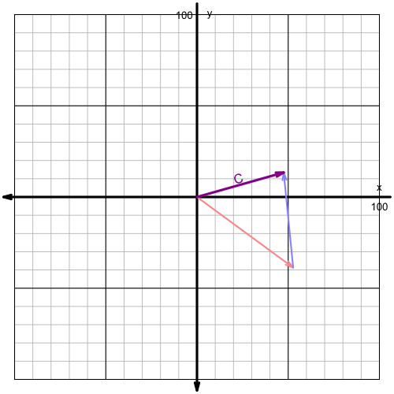

   vector C is the sum of vector A and vector B

   Find the direction (between 0 and $2\pi$) and magnitude of vector $\vec{C}$.
   - Direction:
   - Magnitude:

#### Question

8. We are given two vectors: $\vec{A}$ and $\vec{B}$. Each vector has a direction and magnitude. The direction is given in radians counterclockwise from the positive $x$ axis. The magnitude is the length of the vector.

   Vector $\vec{A}$ is directed 1.66 radians counterclockwise from the positive $x$ axis, and it has a magnitude of 61.7.

   $$\theta_{\vec{A}}=1.66$$
   $$||\vec{A}||=61.7$$

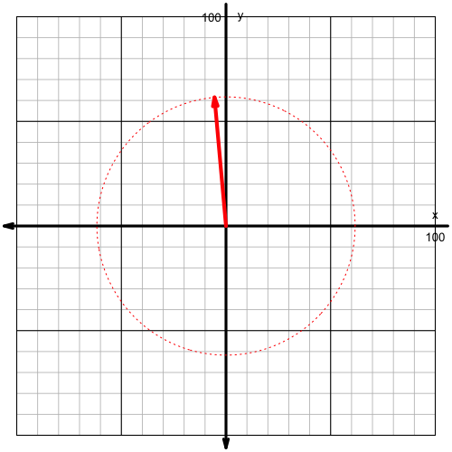

   vector A

   Vector $\vec{B}$ is directed 3.85 radians counterclockwise from the positive $x$ axis, and it has a magnitude of 56.7.

   $$\theta_{\vec{B}}=3.85$$
   $$||\vec{B}||=56.7$$

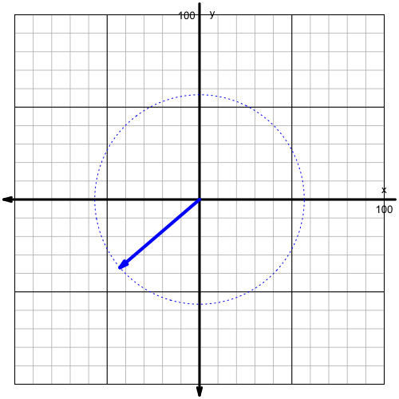

   vector B

   We are interested in a third vector, $\vec{C}$, which is the sum of the other two vectors.

   $$\vec{C}=\vec{A}+\vec{B}$$

   Graphically, to find the sum of two vectors, place the foot of the second vector at the head of the first vector, and then the resultant sum is the vector that goes from the foot of the first vector to the head of the second (shifted) vector. This will be easier to understand graphically:

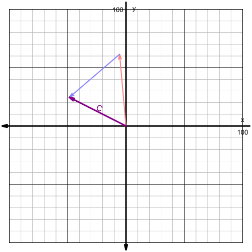

   vector C is the sum of vector A and vector B

   Find the direction (between 0 and $2\pi$) and magnitude of vector $\vec{C}$.
   - Direction:
   - Magnitude: